# 第3講 回帰分析

統計データ解析

Published

October 9, 2025

## 準備

以下で利用する共通パッケージを読み込む．[^1]

<sup>1</sup> 必要なパッケージは適宜追加して良い．

```r
library(conflicted) # 関数名の衝突を警告
conflicts_prefer(   # 優先的に使う関数を指定
  dplyr::filter(),
  dplyr::select(),
  dplyr::lag(),
  )
library(tidyverse)
library(broom)      # 解析結果を tibble 形式に集約
library(gt)         # 表の作成
```

## 回帰係数の推定

**回帰係数の推定**

回帰係数は関数 `stats::lm()` を用いて推定することができる．

```r
lm(formula, data, subset, weights, na.action,
   method = "qr", model = TRUE, x = FALSE, y = FALSE, qr = TRUE,
   singular.ok = TRUE, contrasts = NULL, offset, ...)
#' formula: 目的変数名 ~ 説明変数名(複数ある場合は + で並べる)
#' data: 目的変数，説明変数を含むデータフレーム
#' subset: 推定に用いるデータフレームの部分集合を指定(指定しなければ全て)
#' na.action: 欠損の扱いを指定(既定値はoption("na.action")で設定された処理)
#' model,x,y,qr: 返値にmodel.frame,model.matrix,目的変数,QR分解を含むか指定
```

**実行例**

配布データ `wine.csv` を用いた ボルドーワインの価格と気候の関係に関する回帰分析は以下で実行できる．

```r
bw_data <- read_csv(file="data/wine.csv")  # データの読み込み
bw_fit <- lm(formula = LPRICE2 ~ . - VINT, # VINTを除く全て
             data = bw_data)
bw_fit # 推定結果の簡単な表示
```

```
Call:
lm(formula = LPRICE2 ~ . - VINT, data = bw_data)

Coefficients:
(Intercept)        WRAIN      DEGREES        HRAIN      TIME_SV
 -12.145334     0.001167     0.616392    -0.003861     0.023847
```

### 問題 (広告費と売上データ)

データセット https://www.statlearning.com/s/Advertising.csv は 広告費(TV,radio,newspapers)と売上の関係を調べたもの [^2] である． このデータセットを用いて以下の回帰式を推定しなさい．

<sup>2</sup> Datasets in this presentation are taken from “An Introduction to Statistical Learning, with applications in R” (Springer, 2013) with permission from the authors: G. James, D. Witten, T. Hastie and R. Tibshirani. [参考](https://www.statlearning.com)

```r
formula = sales ~ TV
formula = sales ~ radio
formula = sales ~ TV + radio
```

### 解答例

データの読み込みを行う．

```r
adv_data <- read_csv("https://www.statlearning.com/s/Advertising.csv")
```

GGally パッケージを利用して散布図を描く．[^3]

<sup>3</sup> 標準設定では図は横長で描画される．この例では縦横が同じ大きさ(7inch)になるように指定している．

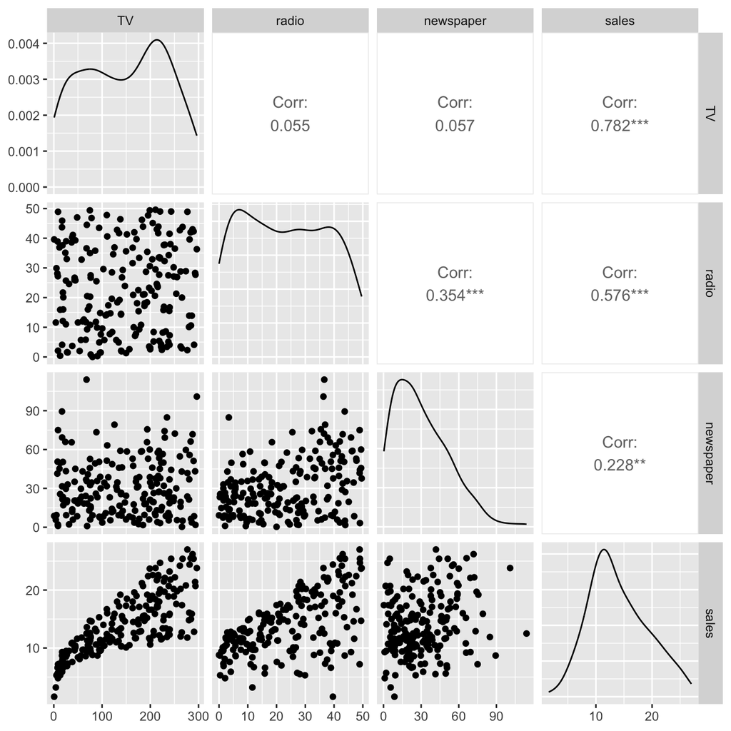

```r
GGally::ggpairs(adv_data, columns = 2:5)
```

“TV” の宣伝費で売上を説明する．

```r
(adv_lm1 <- lm(sales ~ TV, data = adv_data))
```

```
Call:
lm(formula = sales ~ TV, data = adv_data)

Coefficients:
(Intercept)           TV
    7.03259      0.04754
```

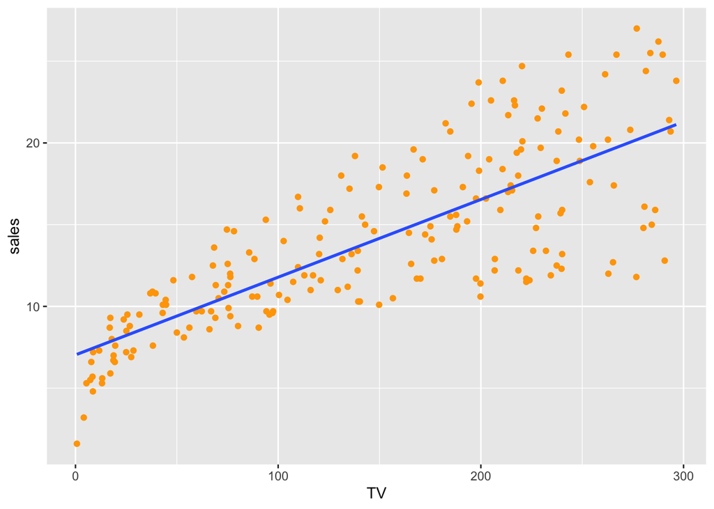

```r
adv_data |>
    ggplot(aes(x = TV, y = sales)) +
    geom_point(colour = "orange") +
    geom_smooth(method = lm, se = FALSE)
```

“radio” の宣伝費で売上を説明する．

```r
(adv_lm2 <- lm(sales ~ radio, data = adv_data))
```

```
Call:
lm(formula = sales ~ radio, data = adv_data)

Coefficients:
(Intercept)        radio
     9.3116       0.2025
```

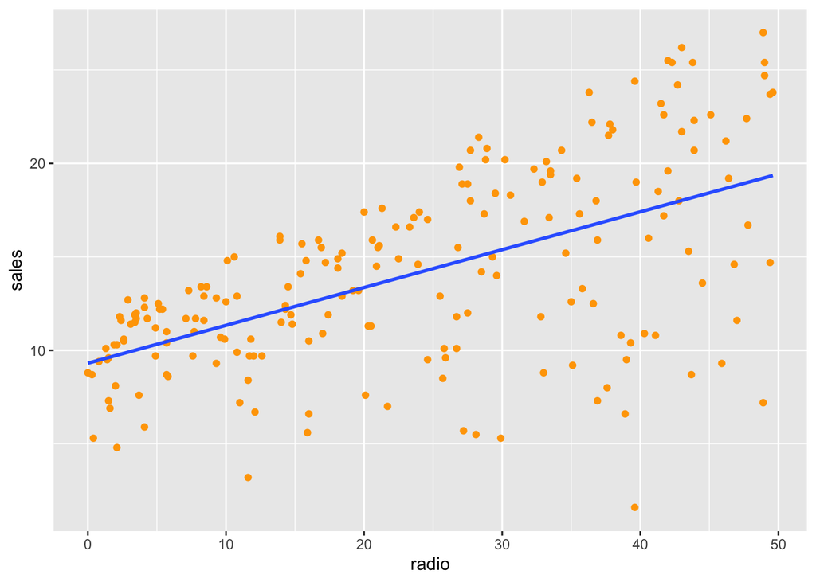

```r
adv_data |>
    ggplot(aes(x = radio, y = sales)) +
    geom_point(colour = "orange") +
    geom_smooth(method = lm, se = FALSE)
```

両者の宣伝費で売上を説明する．

```r
(adv_lm3 <- lm(sales ~ TV + radio, data = adv_data))
```

```
Call:
lm(formula = sales ~ TV + radio, data = adv_data)

Coefficients:
(Intercept)           TV        radio
    2.92110      0.04575      0.18799
```

3次元の散布図を描くには `scatterplot3d` パッケージを利用することができる．

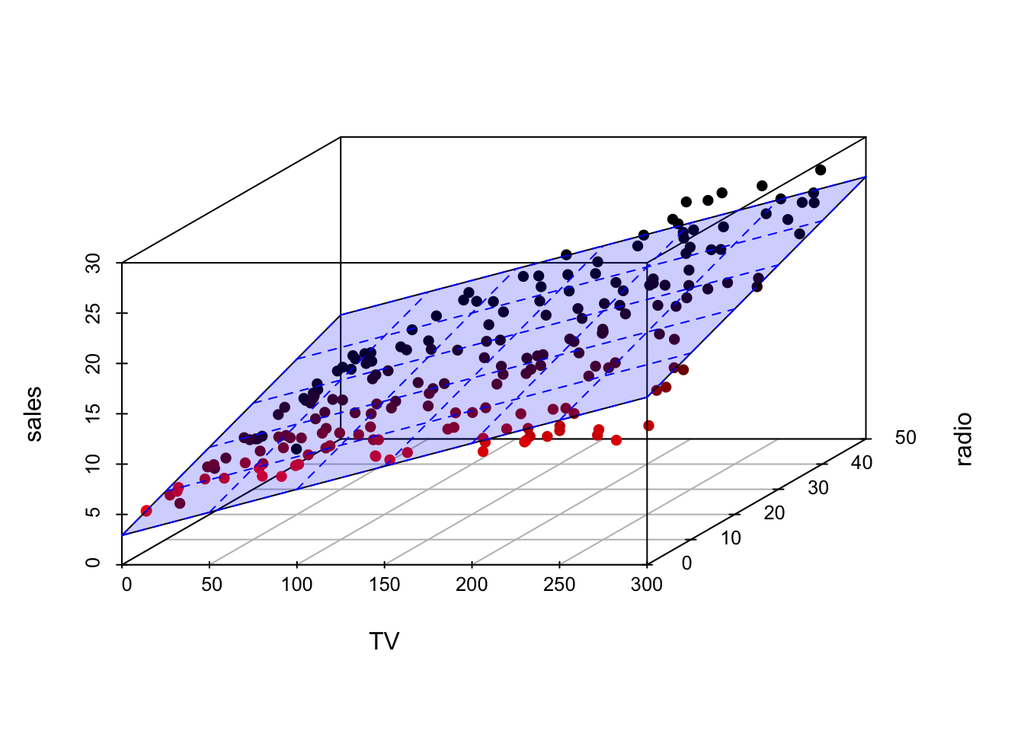

Figure 1: scatterplot3d による3次元散布図の例

```r
library(scatterplot3d)
s3d <- with(adv_data,
            scatterplot3d(
                x = TV, y = radio, z = sales,
                type = "p",         # plotの種類: "p"点，"l"線，"h"足付き
                pch = 16,           # 点の種類 (?points 参照)
                angle = 45,         # xy平面の見る方向 (適宜調整)
                highlight.3d = TRUE # 高さ(z)ごとに色を変える
            ))
s3d$plane3d(adv_lm3, col = "blue",  # 回帰式の定める平面の追加
            draw_polygon = TRUE,    # 平面の塗り潰しの設定
            polygon_args = list(col = rgb(0,0,1,0.2)))
```

### 問題 (東京の気候データ)

配布したデータセット `tokyo_weather.csv` は 気象庁より取得した東京の気候データを回帰分析用に整理したもの [^4] である． このデータセットのうち，9月の気候データを用いて，以下の回帰式を推定しなさい．

<sup>4</sup> [参考](https://www.data.jma.go.jp/gmd/risk/obsdl/index.php)

```r
formula = temp ~ solar + press
```

### 解答例

データの読み込みを行う．

```r
tw_data <- read_csv("data/tokyo_weather.csv")
```

9月の”気温”を目的変数，“日射量・気圧”を説明変数とするモデルの推定を行う．

```r
tw_formula <- temp ~ solar + press       # モデル式の定義
class(tw_formula)                        # formula class であることを確認
```

```
[1] "formula"
```

```r
(tw_lm <- lm(tw_formula,                 # 回帰係数の推定
             data = tw_data,
             subset =  month==9))        # 9月のデータの抽出
```

```
Call:
lm(formula = tw_formula, data = tw_data, subset = month == 9)

Coefficients:
(Intercept)        solar        press
   386.2285       0.3020      -0.3602
```

```r
(tw_df <- as_tibble(model.frame(tw_lm))) # 推定に用いたデータフレームの抽出
```

```
# A tibble: 30 × 3
    temp solar press
   <dbl> <dbl> <dbl>
 1  29.2 24.0  1012.
 2  29.6 22.1  1010.
 3  29.1 18.6  1011.
 4  26.1  7.48 1008.
 5  29.3 22.6  1005.
 6  27.5 13.2  1004.
 7  27   11.0  1008.
 8  21.9  2.1  1008.
 9  24.8  8.81 1007.
10  27.8 17.6  1009.
# ℹ 20 more rows
```

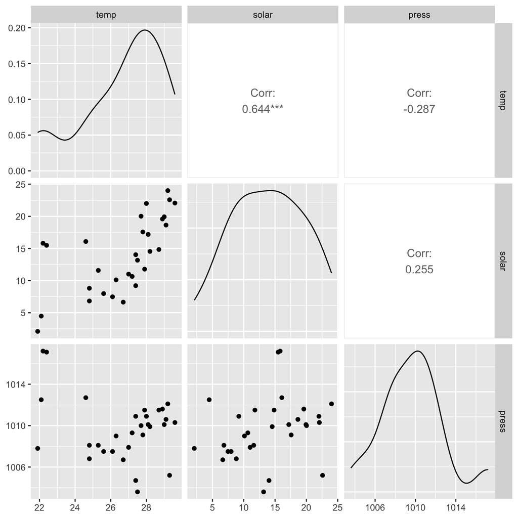

```r
GGally::ggpairs(tw_df) # 散布図
```

散布図と回帰式の定める平面の描画の3次元プロットを行う．

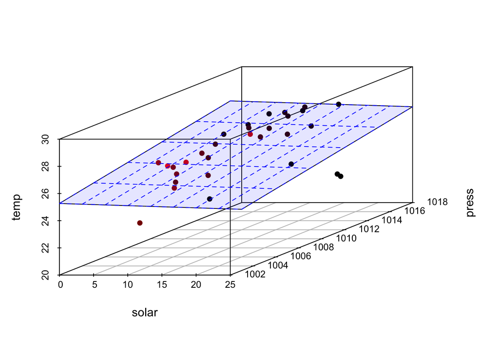

```r
s3d <- with(tw_df,
            scatterplot3d(
                x = solar, y = press, z = temp,
                type = "p",         # plotの種類: "p"点，"l"線，"h"足付き
                pch = 16,           # 点の種類 (?points 参照)
                angle = 30,         # xy平面の見る方向 (適宜調整)
                highlight.3d = TRUE # 高さ(z)ごとに色を変える
            ))
s3d$plane3d(tw_lm, col = "blue",    # 回帰式の定める平面の追加
            draw_polygon = TRUE,    # 平面の塗り潰しの設定
            polygon_args = list(col = rgb(0,0,1,0.1)))
```

## 最小二乗推定量の性質

**情報の取得**

関数 `stats::lm()` の出力には様々な情報が含まれる．

```r
base::summary(lmの出力)       # 推定結果のまとめ
stats::coef(lmの出力)         # 推定された回帰係数
stats::fitted(lmの出力)       # あてはめ値
stats::resid(lmの出力)        # 残差
stats::model.frame(lmの出力)  # modelに必要な変数の抽出 (データフレーム)
stats::model.matrix(lmの出力) # デザイン行列
```

関数 `base::summary()` の tidyverse 版として `package::broom` が用意されている． 関数 `stats::lm()` の結果を tibble 形式で表示することができる．

```r
broom::tidy(lmの出力)    # 推定結果のまとめ．coef(summary(lmの出力)) と同様
broom::glance(lmの出力)  # 評価指標(統計量)のまとめ．決定係数やF値などを整理
broom::augment(lmの出力) # 入出力データのまとめ．あてはめ値・残差などを整理
```

**ベクトルと行列の計算**

データフレーム以外の重要なデータ構造として以下の2つがある．

- ベクトル (vector) : 1次元の配列
- 行列 (matrix) : 2次元の同じデータ型の配列

データフレーム(の一部)は 必要であればベクトルと行列に明示的に変換できる．

```r
as.vector(データフレーム[列名]) # base::as.vector()
as_vector(データフレーム[列名]) # purrr::as_vector()
as.matrix(データフレーム) # base::as.matrix()
#' データフレームを行列に変換する場合は全て同じデータ型でなくてはならない
```

代表的な行列とベクトルの計算は以下のようにする．

- 行列 $A,B$ の積 $AB$ および ベクトル $a,b$ の内積 $a\cdot b$

  ```r
  A %*% B # 行列の大きさは適切である必要がある
  a %*% b # ベクトルは同じ長さである必要がある
  ```

- 正方行列 $A$ の逆行列 $A^{-1}$

  ```r
  solve(A) # 他にもいくつか関数はある
  ```

- $X^{\mathsf{T}}Y$ および $X^{\mathsf{T}}X$ の計算

  ```r
  crossprod(X, Y) # cross product の略
  #' X: 行列 (またはベクトル)
  #' Y: 行列 (またはベクトル)
  crossprod(X) # 同じものを掛ける場合は引数は1つで良い
  ```

  行列の転置を計算する関数 `t()` と積を組み合わせてもよい．

  ```r
  crossprod(X,Y) = t(X) %*% Y
  #' XY^T = (X^TY)^T を計算する関数 tcrossprod() もある
  tcrossprod(X,Y) = X %*% t(Y)
  ```

### 問題

前問の推定結果を用いて，最小二乗推定量の以下の性質を確認しなさい．

- 推定された係数が正規方程式の解となること．
  $$\begin{equation}
  \boldsymbol{\hat{\beta}}
  =
  (X^{\mathsf{T}}X)^{-1}X^{\mathsf{T}}\boldsymbol{y}
  \end{equation}$$
- あてはめ値と残差が直交すること．
- 回帰式が標本平均を通ること．

### 解答例

広告費と売上データの回帰分析において， 回帰係数と正規方程式の解の一致は以下の計算で確認できる．

```r
(beta <- coef(adv_lm3))        # 推定された回帰係数
```

```
(Intercept)          TV       radio
 2.92109991  0.04575482  0.18799423
```

```r
X <- model.matrix(adv_lm3)     # デザイン行列
Y <- model.frame(adv_lm3)[[1]] # 目的変数 (データフレームの1列目のベクトル)
solve(crossprod(X)) %*% crossprod(X, Y) # 正規方程式の解
```

```
                  [,1]
(Intercept) 2.92109991
TV          0.04575482
radio       0.18799423
```

あてはめ値と残差の直交性はベクトルの内積を利用すればよい．

```r
yhat <- fitted(adv_lm3) # あてはめ値
ehat <- resid(adv_lm3)  # 残差
yhat %*% ehat           # 直交すれば内積はO
```

```
              [,1]
[1,] -2.337233e-13
```

回帰式が標本平均を通ることは説明変数の平均のあてはめ値を求めて比較すればよい．

```r
colMeans(X) %*% beta # 説明変数の標本平均のあてはめ値
```

```
        [,1]
[1,] 14.0225
```

```r
mean(Y)              # 目的変数の標本平均
```

```
[1] 14.0225
```

東京の気候データにおいても同様に確認できる．

```r
(beta <- coef(tw_lm))                   # 推定された回帰係数
```

```
(Intercept)       solar       press
386.2284847   0.3019861  -0.3602392
```

```r
(X <- model.matrix(tw_lm))              # デザイン行列
```

```
    (Intercept) solar  press
244           1 24.01 1012.1
245           1 22.07 1010.3
246           1 18.64 1010.6
247           1  7.48 1007.5
248           1 22.58 1005.2
249           1 13.17 1003.6
250           1 11.01 1007.9
251           1  2.10 1007.8
252           1  8.81 1006.8
253           1 17.57 1009.1
254           1 17.19 1010.1
255           1 20.02 1010.0
256           1 22.00 1010.9
257           1 14.54 1009.9
```

[output cut: 18 more lines]

```r
(Y <- model.frame(tw_lm)[[1]])          # 目的変数 (データフレームの1列目のベクトル)
```

```
 [1] 29.2 29.6 29.1 26.1 29.3 27.5 27.0 21.9 24.8 27.8 28.1 27.7 28.0 28.2 27.4
[16] 27.9 28.7 28.9 29.0 27.2 26.7 24.8 22.1 22.2 22.4 24.6 25.3 27.4 26.3 25.6
```

```r
solve(crossprod(X)) %*% crossprod(X, Y) # 正規方程式の解
```

```
                   [,1]
(Intercept) 386.2284847
solar         0.3019861
press        -0.3602392
```

```r
yhat <- fitted(tw_lm) # あてはめ値
ehat <- resid(tw_lm)  # 残差
yhat %*% ehat         # 直交すれば内積はO(に近い値)となる
```

```
             [,1]
[1,] 1.123776e-14
```

```r
colMeans(X) %*% beta # 説明変数の標本平均のあてはめ値
```

```
         [,1]
[1,] 26.69333
```

```r
mean(Y)              # 目的変数の標本平均
```

```
[1] 26.69333
```

関数 `stats::model.matrix()` の返値は matrix class である． 関数 `stats::model.frame()` の返値は data.frame class であり，`model.frame(...)[[k]]` は data.frame ではなく vector になる． `tibble(...)[[k]]` は vector となるが，`tibble(...)[k]` は vector ではなく1列の tibble になるので注意する． 関数 `base::crossprod()` の引数は厳密に vector/matrix であることを要請するが， 例えば `adv_data` は全て数値なので行列に変換して計算できる．

```r
crossprod(adv_data) # データフレームのままなので計算できない
crossprod(as.matrix(adv_data)) # 計算できる
```

## 残差の分解

### 問題

前問の結果を用いて，残差の性質として以下の分解が成り立つことを確認しなさい．

$$\begin{equation}
(\boldsymbol{y}-\bar{\boldsymbol{y}})^{\mathsf{T}}
(\boldsymbol{y}-\bar{\boldsymbol{y}})
=
(\boldsymbol{y}-\boldsymbol{\hat{y}})^{\mathsf{T}}
(\boldsymbol{y}-\boldsymbol{\hat{y}})+
(\boldsymbol{\hat{y}}-\bar{\boldsymbol{y}})^{\mathsf{T}}
(\boldsymbol{\hat{y}}-\bar{\boldsymbol{y}})
\end{equation}$$

$$\begin{equation}
S_y=S+S_r
\end{equation}$$

### 解答例

広告費と売上データでは以下のように確認できる．

```r
summary(adv_lm3)
```

```
Call:
lm(formula = sales ~ TV + radio, data = adv_data)

Residuals:
    Min      1Q  Median      3Q     Max
-8.7977 -0.8752  0.2422  1.1708  2.8328

Coefficients:
            Estimate Std. Error t value Pr(>|t|)
(Intercept)  2.92110    0.29449   9.919   <2e-16 ***
TV           0.04575    0.00139  32.909   <2e-16 ***
radio        0.18799    0.00804  23.382   <2e-16 ***
---
Signif. codes:  0 '***' 0.001 '**' 0.01 '*' 0.05 '.' 0.1 ' ' 1

Residual standard error: 1.681 on 197 degrees of freedom
Multiple R-squared:  0.8972,    Adjusted R-squared:  0.8962
F-statistic: 859.6 on 2 and 197 DF,  p-value: < 2.2e-16
```

```r
Y <- model.frame(adv_lm3)[[1]]           # 目的変数の取得
(Sy <- sum((Y-mean(Y))^2))               # 目的変数のばらつき
```

```
[1] 5417.149
```

```r
(S <- sum(resid(adv_lm3)^2))             # 残差のばらつき
```

```
[1] 556.914
```

```r
(Sr <- sum((fitted(adv_lm3)-mean(Y))^2)) # 回帰のばらつき
```

```
[1] 4860.235
```

```r
S+Sr                                     # Sy と同じになっている
```

```
[1] 5417.149
```

東京の気候データも同様に確認できる． 以下の例では目的変数を推定結果に含める `lm()` のオプションを利用している．

```r
tw_formula                             # モデルの確認
```

```
temp ~ solar + press
```

```r
tw_lm <- lm(tw_formula,
            data = tw_data,
            subset = month == 9,       # 9月のデータの抽出
            y = TRUE)                  # 目的変数をyとして返すように指定
Y <- with(tw_lm, y)                    # 目的変数の取得 (tw_lm$y でも可)
(Sy <- sum((Y-mean(Y))^2))             # 目的変数のばらつき
```

```
[1] 151.0787
```

```r
(S <- sum(resid(tw_lm)^2))             # 残差のばらつき
```

```
[1] 55.66168
```

```r
(Sr <- sum((fitted(tw_lm)-mean(Y))^2)) # 回帰のばらつき
```

```
[1] 95.41699
```

```r
S+Sr                                   # Sy と同じになっている
```

```
[1] 151.0787
```

関数 `base::summary()` で得られる情報は， 関数 `broom::tidy()` および関数 `broom::glance()` を用いると tibble 形式のデータフレームとして取得できる．

関数 `stats::resid()` や `stats::fitted()` で得られる値は同様に 関数 `broom::augumet()` で取得できる．

```r
tidy(adv_lm3)    # 推定量に関する情報
```

```
# A tibble: 3 × 5
  term        estimate std.error statistic  p.value
  <chr>          <dbl>     <dbl>     <dbl>    <dbl>
1 (Intercept)   2.92     0.294        9.92 4.57e-19
2 TV            0.0458   0.00139     32.9  5.44e-82
3 radio         0.188    0.00804     23.4  9.78e-59
```

```r
glance(adv_lm3)  # 推定結果を評価する統計量
```

```
# A tibble: 1 × 12
  r.squared adj.r.squared sigma statistic  p.value    df logLik   AIC   BIC
      <dbl>         <dbl> <dbl>     <dbl>    <dbl> <dbl>  <dbl> <dbl> <dbl>
1     0.897         0.896  1.68      860. 4.83e-98     2  -386.  780.  794.
# ℹ 3 more variables: deviance <dbl>, df.residual <int>, nobs <int>
```

```r
augment(adv_lm3) # 残差やあてはめ値など
```

```
# A tibble: 200 × 9
   sales    TV radio .fitted  .resid    .hat .sigma   .cooksd .std.resid
   <dbl> <dbl> <dbl>   <dbl>   <dbl>   <dbl>  <dbl>     <dbl>      <dbl>
 1  22.1 230.   37.8   20.6   1.54   0.0140    1.68 0.00406       0.925
 2  10.4  44.5  39.3   12.3  -1.95   0.0188    1.68 0.00871      -1.17
 3   9.3  17.2  45.9   12.3  -3.04   0.0295    1.67 0.0341       -1.83
 4  18.5 152.   41.3   17.6   0.883  0.0124    1.68 0.00117       0.528
 5  12.9 181.   10.8   13.2  -0.324  0.00951   1.69 0.000120     -0.194
 6   7.2   8.7  48.9   12.5  -5.31   0.0347    1.64 0.124        -3.22
 7  11.8  57.5  32.8   11.7   0.0818 0.0129    1.69 0.0000105     0.0490
 8  13.2 120.   19.6   12.1   1.09   0.00576   1.68 0.000823      0.653
 9   4.8   8.6   2.1    3.71  1.09   0.0271    1.68 0.00401       0.658
10  10.6 200.    2.6   12.6  -1.95   0.0171    1.68 0.00797      -1.17
# ℹ 190 more rows
```